# Supervised Learning - Foundations Project: ReCell

### TEST FOR LINEARITY AND INDEPENDENCE

- We will test for linearity and independence by making a plot of fitted values vs residuals and checking for patterns.
- If there is no pattern, then we say the model is linear and residuals are independent.
- Otherwise, the model is showing signs of non-linearity and residuals are not independent.

```python
# let us create a dataframe with actual, fitted and residual values
df_pred = pd.DataFrame()

df_pred["Actual Values"] = y_train  # actual values
df_pred["Fitted Values"] = olsmod2.fittedvalues  # predicted values
df_pred["Residuals"] = olsmod2.resid  # residuals

df_pred.head()
```

|  | Actual Values | Fitted Values | Residuals |
| --- | --- | --- | --- |
| 2068 | 3.882388 | 4.043354 | -0.160966 |
| 2196 | 4.844738 | 4.786592 | 0.058146 |
| 2356 | 5.555978 | 5.125263 | 0.430715 |
| 3060 | 3.789177 | 3.742614 | 0.046563 |
| 1671 | 4.768479 | 4.609762 | 0.158717 |

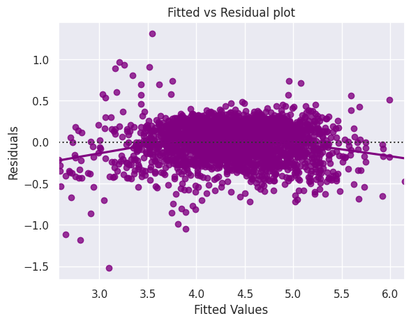

```python
# let's plot the fitted values vs residuals

sns.residplot(
    data=df_pred, x="Fitted Values", y="Residuals", color="purple", lowess=True
)
plt.xlabel("Fitted Values")
plt.ylabel("Residuals")
plt.title("Fitted vs Residual plot")
plt.show()
```

*Observations*

1. The scatter plot shows the distribution of residuals (errors) vs fitted values (predicted values).
2. If there exist any pattern in this plot, we consider it as signs of non-linearity in the data and a pattern means that the model doesn't capture non-linear effects.
3. We see no pattern in the plot above. Hence, the assumptions of linearity and independence are satisfied.

### TEST FOR NORMALITY

- We will test for normality by checking the distribution of residuals, by checking the Q-Q plot of residuals, and by using the Shapiro-Wilk test.
- If the residuals follow a normal distribution, they will make a straight line plot, otherwise not.
- If the p-value of the Shapiro-Wilk test is greater than 0.05, we can say the residuals are normally distributed.

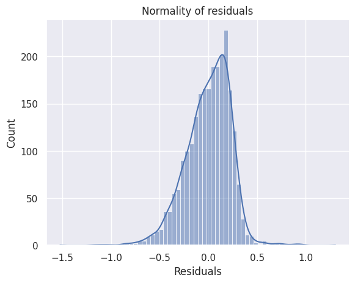

```python
sns.histplot(data=df_pred, x="Residuals", kde=True)
plt.title("Normality of residuals")
plt.show()
```

*Observations*

- The histogram of residuals does have a bell shape.
- Let's check the Q-Q plot.

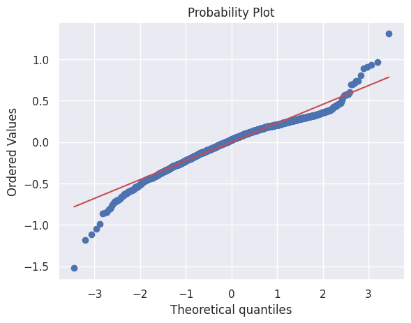

```python
import pylab
import scipy.stats as stats

stats.probplot(df_pred["Residuals"], dist="norm", plot=pylab)
plt.show()
```

*Observations*

- The residuals more or less follow a straight line except for the tails.
- Let's check the results of the Shapiro-Wilk test.

```python
stats.shapiro(df_pred["Residuals"])
```

```
ShapiroResult(statistic=0.9651971120960432, pvalue=1.0420379218461168e-23)
```

*Observations*

- Since p-value < 0.05, the residuals are not normal as per the Shapiro-Wilk test.
- In the real sense of the word, the residuals are not normal.
- However, as an approximation, we can accept this distribution as close to being normal.
- **So, the assumption is satisfied.**

### TEST FOR HOMOSCEDASTICITY

- We will test for homoscedasticity by using the goldfeldquandt test.
- If we get a p-value greater than 0.05, we can say that the residuals are homoscedastic. Otherwise, they are heteroscedastic.

```python
import statsmodels.stats.api as sms
from statsmodels.compat import lzip

name = ["F statistic", "p-value"]
test = sms.het_goldfeldquandt(df_pred["Residuals"], x_train3)
lzip(name, test)
```

```
[('F statistic', 1.109541904946619), ('p-value', 0.036165240726466735)]
```

## Predictions on test data

```python
# predictions on the test set
pred = olsmod2.predict(x_test3)

df_pred_test = pd.DataFrame({"Actual": y_test, "Predicted": pred})
df_pred_test.sample(10, random_state=1)
```

|  | Actual | Predicted |
| --- | --- | --- |
| 2511 | 4.761832 | 4.506233 |
| 1134 | 4.640151 | 4.512838 |
| 501 | 4.129551 | 4.096629 |
| 1423 | 3.583797 | 3.889019 |
| 3166 | 3.173878 | 3.480182 |
| 3361 | 4.913243 | 5.071943 |
| 2899 | 3.582407 | 4.033548 |
| 368 | 5.083700 | 5.552418 |
| 2591 | 4.926311 | 4.585671 |
| 1135 | 4.142658 | 4.332216 |

*Observations*

1. Our model has returned pretty good prediction results, and the actual and predicted values are comparable
2. While the general predictions are close to the actual values, some instances such as observation 2899 could have bettered the difference between the predicted and actual values of 4.03 vs 3.58, respectively. There's more room for improvement.
3. Overall, the model has good predictive power; however, minor overestimation or underestimation indicates further scope for fine-tuning or the need to explore other modeling techniques to arrive at an even more accurate precision in the results.

## Final Model

Let's recreate the final model and print it's summary to gain insights.

```python
x_train_final = x_train3.copy()
x_test_final = x_test3.copy()
```

```python
olsmodel_final = sm.OLS(y_train, x_train_final).fit()
print(olsmodel_final.summary())
```

```
                              OLS Regression Results
=================================================================================
Dep. Variable:     normalized_used_price   R-squared:                       0.844
Model:                               OLS   Adj. R-squared:                  0.843
Method:                    Least Squares   F-statistic:                     1184.
Date:                   Thu, 10 Oct 2024   Prob (F-statistic):               0.00
Time:                           12:59:35   Log-Likelihood:                 110.59
No. Observations:                   2417   AIC:                            -197.2
Df Residuals:                       2405   BIC:                            -127.7
Df Model:                             11
Covariance Type:               nonrobust
========================================================================================
                           coef    std err          t      P>|t|      [0.025      0.975]
----------------------------------------------------------------------------------------
const                    1.4342      0.051     28.367      0.000       1.335       1.533
screen_size              0.0267      0.003      8.719      0.000       0.021       0.033
main_camera_mp           0.0210      0.001     15.458      0.000       0.018       0.024
selfie_camera_mp         0.0149      0.001     13.689      0.000       0.013       0.017
ram                      0.0155      0.004      3.532      0.000       0.007       0.024
weight                   0.0008      0.000      6.740      0.000       0.001       0.001
normalized_new_price     0.4023      0.011     37.365      0.000       0.381       0.423
years_since_release     -0.0158      0.004     -4.505      0.000      -0.023      -0.009
brand_name_Celkon       -0.1178      0.049     -2.405      0.016      -0.214      -0.022
brand_name_Xiaomi        0.0835      0.025      3.361      0.001       0.035       0.132
os_Others               -0.0941      0.029     -3.222      0.001      -0.151      -0.037
4g_yes                   0.0572      0.015      3.855      0.000       0.028       0.086
==============================================================================
Omnibus:                      249.411   Durbin-Watson:                   1.979
Prob(Omnibus):                  0.000   Jarque-Bera (JB):              684.604
Skew:                          -0.563   Prob(JB):                    2.19e-149
Kurtosis:                       5.352   Cond. No.                     2.36e+03
==============================================================================

Notes:
[1] Standard Errors assume that the covariance matrix of the errors is correctly specified.
[2] The condition number is large, 2.36e+03. This might indicate that there are
strong multicollinearity or other numerical problems.
```

```python
# checking model performance on train set (seen 70% data)
print("Training Performance\n")
olsmodel_final_train_perf = model_performance_regression(
    olsmodel_final, x_train_final, y_train
)
olsmodel_final_train_perf
```

```
Training Performance
```

|  | RMSE | MAE | R-squared | Adj. R-squared | MAPE |
| --- | --- | --- | --- | --- | --- |
| 0 | 0.231149 | 0.179771 | 0.844078 | 0.843299 | 4.341622 |

```python
# checking model performance on test set (seen 30% data)
print("Test Performance\n")
olsmodel_final_test_perf = model_performance_regression(
    olsmodel_final, x_test_final, y_test
)
olsmodel_final_test_perf
```

```
Test Performance
```

|  | RMSE | MAE | R-squared | Adj. R-squared | MAPE |
| --- | --- | --- | --- | --- | --- |
| 0 | 0.239601 | 0.186729 | 0.838732 | 0.836842 | 4.465106 |

*Observations*

- The model is able to explain 84% of the variation in the data
- The train and test RMSE and MAE are low and comparable. So, our model is not suffering from overfitting
- MAE suggests that the model can predict prices within a mean error of 0.18 on the test data.
- The MAPE on the test set suggests we can predict within 4.5% of the price
- In conclusion, the model *olsmodel_final* is good for prediction as well as inference purposes.

## Actionable Insights and Recommendations

- Android used devices dominate the market, and account for 93.1% of the market share. The company can build its marketing strategy around this in order to increase its market share and improve profitability.
- Our model is able to explain 84% of the variation in the data and also able to predict within 4.5% of the prices on the test data.
- The model is good for prediction and for inferential purposes.
- The normalized Used_price has some correlation with "screen_size", "selfie_camera", "ram", "battery", "new_price". The company's advertising campaign could utilize this to their advantage to sell more the devices.
- The dataset puts all devices together without specifying which ones are phones and which ones are tablets. Clearly identifying the type of device will help in building seperate models for phones and tablets. This will help in its pricing strategy.
- Understanding customer behavior in the mobile device world is crucial for ReCell in crafting strategies that not only attract customers but also maximize its profitability.
- Some devices are less popular. ReCell could take advantage of product bundling by selling the most popular devices along with the least popular. Bundling will allow its customers to get more value for their money by buying multiple products from ReCell.
- ReCell must have a competent pricing team in place that can develop and implement effective pricing strategies. It could utilize data analytics and machine learning models in this regard. A Data Scientist as part of the team will prove very useful.
- While the general predictions are close to the actual values, some instances such as observation 2899 could have bettered the difference between the predicted and actual values of 4.03 vs 3.58, respectively. There's more room for improvement.
- Overall, the model has good predictive power; however, minor overestimation or underestimation indicates further scope for fine-tuning or the need to explore other modeling techniques to arrive at an even more accurate precision in the results.